# Making plots with `ggplot2`: histograms, boxplots, line graphs

Author

Casey Schine adapted from Emily Malcolm-White

```r
# load packages
library(tidyverse)
library(ggthemes)
```

# Line Graph

This dataset was produced from US economic time series data available from https://fred.stlouisfed.org/. Type `? economics` to learn more.

```r
data("economics")

# what is in the data?
```

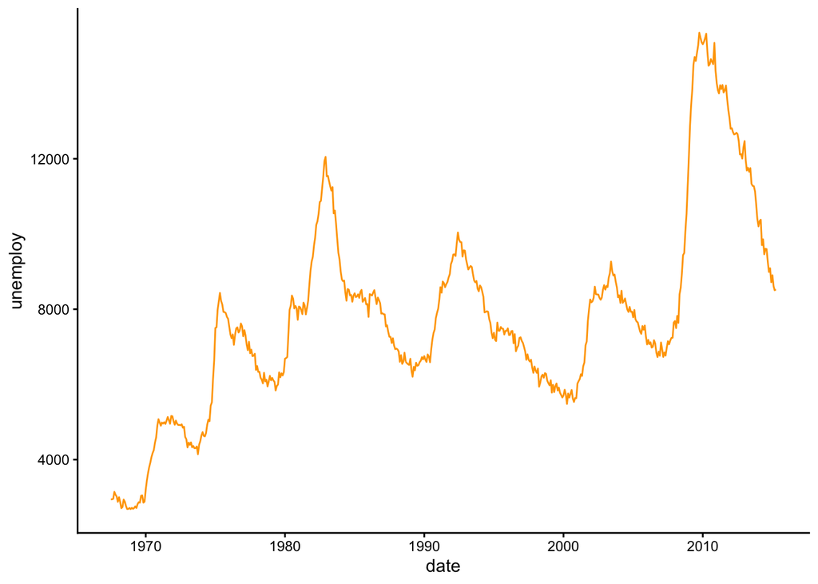

```r
# basic line plot
# add theme
# change color
economics |>
  ggplot(aes(x=date, y=unemploy)) +
  geom_line(color="orange") +
  theme_classic()
```

**Tip**

In ggplot2, you use the **`group`** aesthetic in a `geom_line()` plot when you need to explicitly tell R how to group data points together into lines.

**🌶️ Spicy alert**: I am creating a dataset here using some techniques that might be new to you. Don’t worry so much about *how* I created the dataset, you should focus on what the dataset looks like.

```r
# Example dataset
df <- data.frame(
  time = rep(1:5, 2),
  value = c(1, 3, 5, 7, 9, 2, 5, 8, 11, 14),
  category = rep(c("A", "B"), each = 5)
)

df
```

```
   time value category
1     1     1        A
2     2     3        A
3     3     5        A
4     4     7        A
5     5     9        A
6     1     2        B
7     2     5        B
8     3     8        B
9     4    11        B
10    5    14        B
```

## Without the needed `group` command

```r
# Incorrect: Only one line drawn without group
# with geom_line

# with geom_path
```

## With the `group` command

```r
# Correct: Separate lines for each category using group
```

## Using `color` (or `linetype`) instead

```r
# Automatically groups by color
```

# `possum` data

The possum data frame consists of nine morphometric measurements on each of 104 mountain brushtail possums, trapped at seven Australian sites from Southern Victoria to central Queensland.

There are two different populations (`pop`): `Vic` (Victoria) and `other` (New South Wales or Queensland)

```r
#Be sure to install the DAAG package if you've never used it before...
library(DAAG)
data("possum")
```

# Histograms

**Tip**

Histograms are great for looking at the distributions of numeric variables

```r
# simple histogram


# what do you see?

#change bin size


# not a great choice fo these data
```

You can also customize by color:

```r
# use fill in aes for pop

#what do you see?

# use position="identity" to change how it is plotted
```

Some people prefer to use `geom_density` for a smoother effect:

```r
# first use geom_density to look at full dataset



# use geom density to fix data overlap issue
# use alpha
# add theme
# add axis labels
# change colors


#pass in a filtered dataset
```

# Boxplots

**Tip**

Boxplots are good for displaying the spread, central tendency, and distribution of one numeric variable.

[figure not shown]

Credit: Michael Galarnyk

```r
# boxplot for footlgth


#control color and fill
```

If only one boxplot, it puts weird numbers on the x axis, you may want to use the theme to hide these numbers.

```r
#hide axis elements
# ggplot(possum, aes(y = footlgth)) +
#   geom_boxplot(color = "blue", fill = "lightblue") +
#   theme(
#     axis.text.x = element_blank(),  # Hide text
#     axis.ticks.x = element_blank(), # Hide tick marks
#     axis.title.x = element_blank()  # Hide axis title
#   )
```

**Tip**

Side-by-side boxplots are good for displaying one categorical variable and one numeric variable. One advantage of boxplots over bar plots is that they are able to show a bit about the spread and distribution of the numeric variable!

```r
# same color for both boxplots use footlgth


# different color for both boxplots
#alter the colors


# add a jitter (this is a personal favorite)


# clean up
# remove outliers from boxplot so not putting the same point on twice set outlier.size to 0.
# narrow the jitter using width
```

# Violin Plot

A violin plot is yet another plot type used to show data distribution.

```r
# violin plot using geom_violin
# alter colors and theme
# add labels
```

**Tip**

Histograms, Boxplots, and Violin Plots are all different ways to visualize data distribution. Violin plots and Boxplots are especially good for comparing data distribution between groups.

## In class exersize

Choose one numeric variable from the possum dataset. Create two different distribution plots of that variable (choose from: histogram, density, boxplot, violin). Filter for only one of the populations and then compare across a different grouping variable (other than `Population`).

- Change the theme
- Change the colors

Then write 3–4 sentences:

- What do you see? (Be specific.)
- What does each plot make clearer?
- What does each plot hide or distort?

*There is a spot on the Homework for you to copy your work from this section.*